# Organização de Dados com o Pacote tidyr

## 1.4 Preços vs. Retornos com Dados Reais da Petrobrás

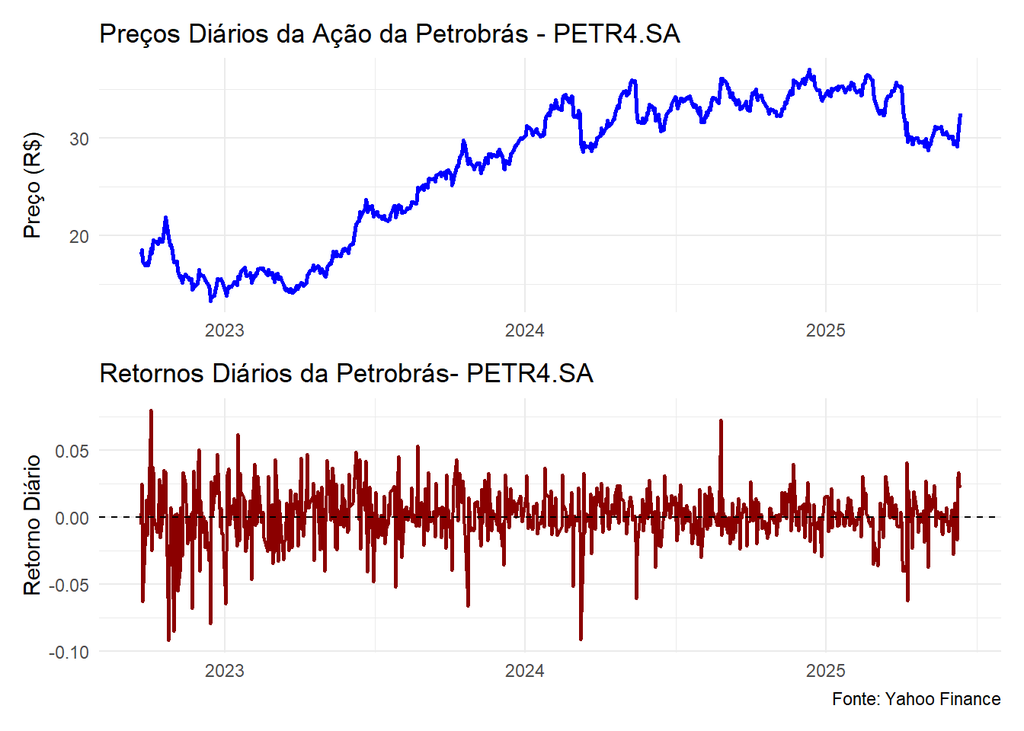

## 1.5 Exercício 1

Para cada uma das situações abaixo, identifique a variável aleatória descrita, classifique-a como **discreta** ou **contínua**:

1. O número mensal de cancelamentos de assinaturas em uma plataforma de streaming

**Variável aleatória: número de cancelamentos Tipo: Discreta (valores inteiros e contáveis)**

2. O tempo de entrega (em horas) para pedidos online de uma loja de e-commerce

**Variável aleatória: tempo de entrega Tipo: Contínua (pode assumir frações de hora, como 12,5h)**

3. A variação percentual diária no preço das ações de uma empresa

**Variável aleatória: variação percentual diária Tipo: Contínua (pode assumir qualquer valor real dentro de um intervalo)**

4. O número de unidades vendidas de um novo produto no primeiro mês após seu lançamento

**Variável aleatória: unidades vendidas Tipo: Discreta (valores inteiros, contáveis)**

## 1.6 Exercício 2

Seguindo o exemplo apresentado na aula sobre o preço da ação da Petrobrás (PETR4.SA), realize uma análise semelhante para outra empresa brasileira de sua escolha. Utilize o pacote yfR conforme demonstrado para baixar os dados dos últimos 200 dias de negociação.

1. Escolha uma empresa brasileira listada na B3 e descubra seu *ticker* (símbolo da ação)
2. Utilize o código apresentado na aula como referência para baixar os dados históricos de preços usando o pacote yfR.
3. Crie um gráfico da série de preços ajustados ao longo do tempo.

```r
# library(yfR)
library(ggplot2)
library(dplyr)

# Define o ticker da empresa (Magazine Luiza)
ticker <- "MGLU3.SA"

# Baixa os dados dos últimos 200 dias úteis
dados_mglu3 <- yf_get(ticker, first_date = Sys.Date() - 365, last_date = Sys.Date())

# Visualiza os primeiros dados
head(dados_mglu3)
```

```
# A tibble: 6 × 11
  ticker   ref_date   price_open price_high price_low price_close   volume
  <chr>    <date>          <dbl>      <dbl>     <dbl>       <dbl>    <dbl>
1 MGLU3.SA 2024-06-17       11.3       11.3      11.0        11.0 14745400
2 MGLU3.SA 2024-06-18       11.0       11.2      10.7        10.9 18214900
3 MGLU3.SA 2024-06-19       10.9       11.1      10.7        11.1 13434100
4 MGLU3.SA 2024-06-20       11.3       11.6      10.6        10.7 35327500
5 MGLU3.SA 2024-06-21       10.7       11.0      10.6        10.8 21829300
6 MGLU3.SA 2024-06-24       11.6       12.4      11.5        12.2 44665500
# ℹ 4 more variables: price_adjusted <dbl>, ret_adjusted_prices <dbl>,
#   ret_closing_prices <dbl>, cumret_adjusted_prices <dbl>
```

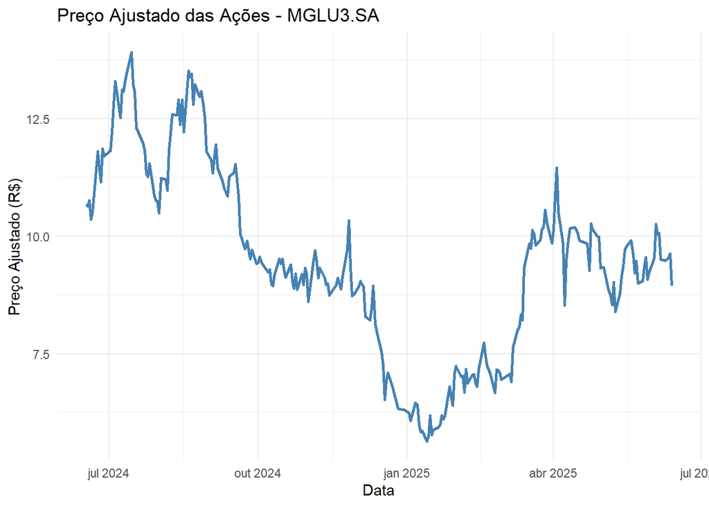

```r
# Cria o gráfico de preços ajustados
ggplot(dados_mglu3, aes(x = ref_date, y = price_adjusted)) +
  geom_line(color = "steelblue", linewidth = 1) +
  labs(
    title = "Preço Ajustado das Ações - MGLU3.SA",
    x = "Data",
    y = "Preço Ajustado (R$)"
  ) +
  theme_minimal()
```

# 2 Distribuições de Probabilidade Teóricas

## 2.1 Simula $X \sim N(\mu = 3, \sigma = 1)$

- Vamos simular uma VA $X$ com distribuição normal com média $\mu = 3$ e desvio-padrão $\sigma = 1$.
- Vamos gerar 1000 observações dessa VA e plotar o histograma dos dados.
- Em seguida, vamos fazer um histograma com densidade empírica sobreposta para os dados simulados e verificar se a distribuição se aproxima da distribuição normal teórica.

```r
# fixa a semente do gerador de numeros aleatórios
set.seed(123)

# simula 1000 observações de uma VA Normal com media 3 e desvio padrao 1
x_simulada <- rnorm(1000, mean = 3, sd = 1)
head(x_simulada)
```

```
[1] 2.4395244 2.7698225 4.5587083 3.0705084 3.1292877 4.7150650
```

```r
# media
mean(x_simulada)
```

```
[1] 3.0161279
```

```r
# desvio padrao
sd(x_simulada)
```

```
[1] 0.99169498
```

## 2.2 Simulação de uma VA com Distribuição Normal

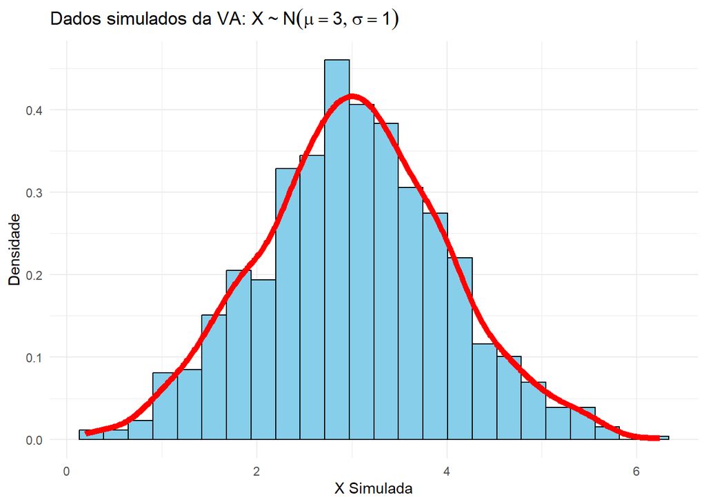

```r
df <- data.frame(x_simulada)

# regra de Freedman-Diaconis para calcular o binwidth
iqr_valores <- IQR(df$x_simulada)
n <- length(df$x_simulada)
binwidth_fd = 2 * iqr_valores / (n^(1/3))

# histograma com densidade empirica
ggplot(df, aes(x = x_simulada)) +
  geom_histogram(
    aes(y = after_stat(density)),
    binwidth = binwidth_fd,
    color = "black",
    fill = "skyblue") +
  geom_density(col = "red", size = 2) +
  labs(title = expression("Dados simulados da VA: " * X %~% N(mu == 3, sigma == 1)),
     x = "X Simulada",
     y = "Densidade") +
theme_minimal()
```

## 2.3 Simula $Z = \frac{X - \mu}{\sigma} \sim N(\mu = 0, \sigma = 1)$

- Vamos gerar 1000 observações dessa VA e plotar um histograma com a densidade empírica sobreposta dos dados.
- Em seguida, vamos fazer um histograma com densidade empírica sobreposta para os dados simulados e verificar se a distribuição se aproxima da distribuição normal teórica:

```r
set.seed(123)

z_simulada <- rnorm(1000, mean = 0, sd = 1)
head(z_simulada)
```

```
[1] -0.560475647 -0.230177489  1.558708314  0.070508391  0.129287735
[6]  1.715064987
```

Simulação de uma VA com Distribuição Normal Padronizada

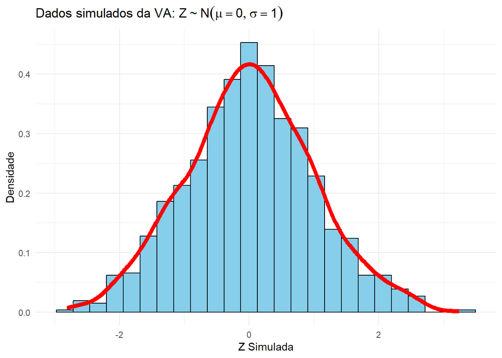

## 2.4 Exercício 1

1. Qual a probabilidade de sofrer uma perda mensal inferior a 4%? Ou seja, encontre $P(R < - 0.04)$.

```r
# Média e desvio-padrão dos retornos mensais
media <- 0.01     # 1%
desvio <- 0.03    # 3%

# Valor alvo da perda
retorno_alvo <- -0.04

# Cálculo da probabilidade P(R < -0.04)
probabilidade <- pnorm(retorno_alvo, mean = media, sd = desvio)

# Exibe o resultado formatado
cat("A probabilidade de sofrer uma perda mensal inferior a 4% é de", round(probabilidade * 100, 2), "%\n")
```

```
A probabilidade de sofrer uma perda mensal inferior a 4% é de 4.78 %
```

2. Qual a probabilidade de obter um retorno positivo no próximo mês? Ou seja encontre $P(R > 0)$.

```r
## Média e desvio-padrão dos retornos mensais
media <- 0.01     # 1%
desvio <- 0.03    # 3%

# Cálculo da probabilidade de retorno positivo: P(R > 0)
prob_positivo <- 1 - pnorm(0, mean = media, sd = desvio)

# Exibe o resultado formatado
cat("A probabilidade de obter um retorno positivo no próximo mês é de", round(prob_positivo * 100, 2), "%\n")
```

```
A probabilidade de obter um retorno positivo no próximo mês é de 63.06 %
```

3. Qual a probabilidade de obter um retorno superior a 5%? Ou seja, encontre $P(R > 0.05)$.

```r
# Média e desvio-padrão dos retornos mensais
media <- 0.01     # 1%
desvio <- 0.03    # 3%

# Valor alvo
retorno_alvo <- 0.05

# Cálculo da probabilidade P(R > 0.05)
probabilidade <- 1 - pnorm(retorno_alvo, mean = media, sd = desvio)

# Exibe o resultado formatado
cat("A probabilidade de obter um retorno superior a 5% é de", round(probabilidade * 100, 2), "%\n")
```

```
A probabilidade de obter um retorno superior a 5% é de 9.12 %
```

## 2.5 Exercício 2

**Cenário**: O departamento de vendas de uma rede varejista analisou dados históricos e determinou que as vendas diárias de seu produto mais popular seguem aproximadamente uma distribuição normal com média de R$ 12.000 e desvio-padrão de R$ 2.500 ($V \sim N(\mu = 12000, \sigma = 2500)$).

1. Qual a probabilidade de que em um determinado dia as vendas excedam R$ 15.000? Ou seja, encontre $P(V > 15000)$.

```r
# Média e desvio-padrão das vendas diárias
media <- 12000
desvio <- 2500

# Valor alvo
vendas_alvo <- 15000

# Cálculo da probabilidade P(V > 15000)
probabilidade <- 1 - pnorm(vendas_alvo, mean = media, sd = desvio)

# Exibe o resultado
cat("A probabilidade de que as vendas excedam R$ 15.000 em um dia é de", round(probabilidade * 100, 2), "%\n")
```

```
A probabilidade de que as vendas excedam R$ 15.000 em um dia é de 11.51 %
```

2. O departamento de operações precisa garantir estoque suficiente para atender a demanda em dias de alto volume de vendas. Se eles desejam ter estoque suficiente para atender 95% dos dias, qual deveria ser o valor mínimo de vendas para o qual eles devem se preparar? Ou seja, encontre o valor $y$ tal que $P(V < y) = 0.95$.

```r
# Média e desvio-padrão das vendas diárias
media <- 12000
desvio <- 2500

# Cálculo do percentil 95: valor de y tal que P(V < y) = 0.95
y <- qnorm(0.95, mean = media, sd = desvio)

# Exibe o resultado
cat("Para atender 95% dos dias, o estoque deve cobrir vendas de até R$", round(y, 2), "\n")
```

```
Para atender 95% dos dias, o estoque deve cobrir vendas de até R$ 16112.13
```

3. Para fins de planejamento financeiro, o gestor precisa determinar o valor mínimo de vendas diárias que pode ser esperado com 90% de probabilidade. Ou seja, encontre o valor $x$ tal que $P(V > x) = 0.90$.

```r
# Média e desvio-padrão das vendas diárias
media <- 12000
desvio <- 2500

# Cálculo do valor x tal que P(V > x) = 0.90 → P(V < x) = 0.10
x <- qnorm(0.10, mean = media, sd = desvio)

# Exibe o resultado
cat("Com 90% de probabilidade, as vendas diárias estarão acima de R$", round(x, 2), "\n")
```

```
Com 90% de probabilidade, as vendas diárias estarão acima de R$ 8796.12
```

# 3 Características da Distribuição de Probabilidade de Variáveis Aleatórias

## 3.1 Função `sample()` em R

```r
# fixa a semente do gerador de numeros aleatórios
set.seed(123)

# listagem da populacao de faturas
listagem_populacao <- 1:1000

# extrai uma ASS com n = 20 da populacao, sem reposição.
sample(listagem_populacao,20)
```

```
 [1] 415 463 179 526 195 938 818 118 299 229 244  14 374 665 602 603 768 709  91
[20] 953
```

- A AAS de tamanho 20 selecionou as faturas de números exibidos acima.

## 3.2 Valor Esperado: Simulação em R

Verificação empírica via simulação:

```r
# Definir o número de lançamentos
lancamentos <- 10000

# Simular os lançamentos do dado
set.seed(123) # Para reprodutibilidade
dado <- c(1, 2, 3, 4, 5, 6)
resultado_dados <- sample(dado, lancamentos, replace = TRUE)

# Calcular o valor esperado (média do número voltado para cima)
media_empirica <- mean(resultado_dados)
media_empirica
```

```
[1] 3.4697
```

**Observação**: À medida que aumentamos o número de lançamentos, a média empírica se aproxima do valor esperado teórico de 3,5.

Esta convergência é explicada pela *Lei dos Grandes Números*: à medida que o número de AA aumenta, a média dos resultados convergirá para o valor esperado (média teórica).

## 3.3 Exemplo: Retorno Esperado de Investimento

Uma empresa analisa um investimento com os seguintes cenários:

| Cenário | Retorno (R$) | Probabilidade |
| --- | --- | --- |
| Pessimista | -50.000 | 0,2 |
| Moderado | 100.000 | 0,5 |
| Otimista | 300.000 | 0,3 |

**Cálculo do Valor Esperado:**

$$\begin{align}
E(X) &= -50.000 \times 0,2 + 100.000 \times 0,5 + 300.000 \times 0,3 \\
&= -10.000 + 50.000 + 90.000 \\
&= 130.000
\end{align}$$

**Interpretação**: O retorno médio esperado é de R$ 130.000, considerando todos os cenários possíveis ponderados por suas probabilidades.

## 3.4 Valor Esperado: Implementação e Simulação em R

```r
# Definir os dados do exemplo de investimento
retornos <- c(-50000, 100000, 300000)
probabilidades <- c(0.2, 0.5, 0.3)

# Cálculo do valor esperado
valor_esperado <- sum(retornos * probabilidades)
valor_esperado
```

```
[1] 130000
```

```r
# Simulação para verificação empírica
set.seed(123)  # Para reprodutibilidade
n_simulacoes <- 10000
indices <- sample(1:3, size = n_simulacoes, prob = probabilidades, replace = TRUE)
retornos_simulados <- retornos[indices]
media_empirica <- mean(retornos_simulados)
media_empirica
```

```
[1] 130645
```

## 3.5 Explicação do Código

Esta técnica de simulação é muito importante em finanças porque nos permite “experimentar” virtualmente um investimento milhares de vezes, observando não apenas a média dos resultados (valor esperado), mas também sua distribuição, variabilidade e comportamento. À medida que aumentamos o número de simulações, a média empírica converge para o valor esperado teórico, conforme previsto pela Lei dos Grandes Números.

## 3.6 Aplicação do Valor Esperado - Exemplo

Uma seguradora oferece seguros para danos residenciais causados por incêndios. Com base em dados históricos, a empresa determinou o seguinte:

- A probabilidade de ocorrer um incêndio em uma residência segurada durante um ano é de 0,01.
- O valor médio da indenização paga em caso de incêndio é de R$ 150.000.

A seguradora deseja calcular o prêmio anual que deve ser cobrado para cobrir os riscos de incêndio, considerando uma margem de 25% para cobrir custos administrativos e obter lucro.

Perguntas:

1. Calcule o valor esperado das indenizações que a seguradora terá que pagar por residência segurada em um ano.
2. Determine o prêmio anual que a seguradora deve cobrar por residência segurada.
3. Escreva um código em R para realizar esses cálculos.
- Usando R:

```r
# Definir os parâmetros
probabilidade_incendio <- 0.01
valor_medio_indenizacao <- 150000
margem <- 0.25

# Calcular o valor esperado das indenizações
valor_esperado_indenizacao <- probabilidade_incendio * valor_medio_indenizacao
valor_esperado_indenizacao
```

```
[1] 1500
```

```r
# Calcular o prêmio anual com a margem
premio_anual <- valor_esperado_indenizacao * (1 + margem)
premio_anual
```

```
[1] 1875
```

1. **Valor Esperado das Indenizações**:

$$E(X) = P(\text{incêndio}) \times \text{valor médio da indenização}$$

Substituindo os valores:

$$E(X) = 0,01 \times 150.000 = R$ 1.500$$

2. **Prêmio Anual**:

Para incluir a margem de 25%:

$$\text{Prêmio} = E(X) \times (1 + \text{margem})$$

Substituindo os valores:

$$\text{Prêmio} = 1.500 \times (1 + 0.25) = 1.500 \times 1.25 = R$ 1.875$$

## 3.7 Exercício 1

Uma empresa precisa escolher entre dois projetos de investimento com os seguintes fluxos de caixa projetados:

**Projeto A**:

- Investimento inicial: R$200.000
- Cenários de retorno:
  - Baixo: R$220.000 (probabilidade 0,3)
  - Médio: R$280.000 (probabilidade 0,4)
  - Alto: R$320.000 (probabilidade 0,3)

**Projeto B**:

- Investimento inicial: R$200.000
- Cenários de retorno:
  - Baixo: R$180.000 (probabilidade 0,2)
  - Médio: R$260.000 (probabilidade 0,5)
  - Alto: R$400.000 (probabilidade 0,3)

**Perguntas**:

1. Calcule o valor esperado do lucro líquido de cada projeto.
2. Baseado apenas no valor esperado, qual projeto seria escolhido?
3. Que outras informações seriam úteis para tomar esta decisão?